# MATH 4720 / MSSC 5720 Statistical Methods

August 23 2020

### with background image

[figure not shown]

[figure not shown]

## test color

[figure not shown]

## Testing footnotes

Some more text.And *another* **footnote**

## Use two hashes (##) to set a frame’s header

Render bullets incrementally for some slides but not others you can (ab)use this syntax for blockquotes

- Eat eggs
- Drink coffee

## Slide with Bullets

Here are some interesting sentences.

## Background images

- data-background=mu_blue.png
- data-background-size=cover, 100px, 50%, …
- data-background-position=center, left, right, …
- check https://www.w3schools.com/cssref/css3_pr_background.asp

## Code highlighting

```r
x <- 10
y <- x * 2
z <- 1 + 3
yy <- exp(4) + log(10)
```

When you want to help the audience focus exclusively on the highlighted region press the h key and the rest of the code will fade away.

## Slide with R Output

```r
summary(cars)
```

```
##      speed           dist
##  Min.   : 4.0   Min.   :  2.00
##  1st Qu.:12.0   1st Qu.: 26.00
##  Median :15.0   Median : 36.00
##  Mean   :15.4   Mean   : 42.98
##  3rd Qu.:19.0   3rd Qu.: 56.00
##  Max.   :25.0   Max.   :120.00
```

## Slide with Plot

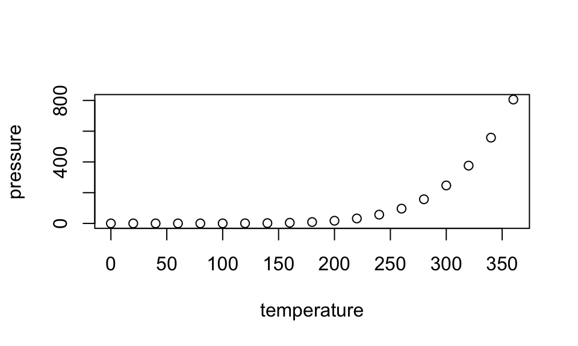

## Tables

```markdown
First Header  | Second Header
------------- | -------------
Content Cell  | Content Cell
Content Cell  | Content Cell
```

| First Header | Second Header |
| --- | --- |
| Content Cell | Content Cell |
| Content Cell | Content Cell |

You can center content on a slide by adding the .flexbox and .vcenter attributes to the slide title.

## horizontally center content

This text is centered.

## two-column layout using the columns-2 class

[figure not shown]

MU

- Bullet 1
- Bullet 2
- Bullet 3

## Text color

You can color content using base color classes red, blue, green, yellow, and gray (or variations of them, e.g., red2, red3, blue2, blue3, etc.).

This text is red2

## Presenter mode

To enable presenter mode add ?presentme=true to the URL of the presentation. For example: my-presentation.html?presentme=true

The presenter mode window will open and will always re-open with the presentation until it is disabled with: my-presentation.html?presentme=false

## Data frame printing

- check https://bookdown.org/yihui/rmarkdown/html-document.html#data-frame-printing

| Grade | Percentage |
| --- | --- |
| A | [94, 100] |
| A- | [90, 94) |
| B+ | [87, 90) |
| B | [84, 87) |
| B- | [80, 84) |
| C+ | [77, 80) |
| C | [74, 77) |
| C- | [70, 74) |
| D+ | [67, 70) |
| D | [64, 67) |
| D- | [60, 64) |
| F | [0, 60) |

- use four hyphens (- - - -) to create a new frame without a header

## Add picture

- add picture using

[figure not shown]

```markdown
![caption](path)
```

## Display Modes

- ‘f’ enable fullscreen mode
- ‘w’ toggle widescreen mode
- ‘o’ enable overview mode
- ‘h’ enable code highlight mode
- ‘p’ show presenter notes

## Code - HTML

```html
<div class="notes">
This is my *note*.

- It can contain markdown
- like this list

</div>
```

## Code - CSS

```css
#nextsteps {
   color: blue;
}

.emphasized {
   font-size: 1.2em;
}
```

## Code - Markdown

```markdown
A friend once said:

> It's always better to give
> than to receive.
```

```markdown
---
output:
  ioslides_presentation:
    incremental: true
---
```

## Font color

- Roses are red,
- violets are blue.

## Includes

- include content in the document header or before/after the document body
- includes:
  - in_header: header.html
  - before_body: doc_prefix.html
  - after_body: doc_suffix.html

## Share Options

- include a file named _output.yaml within the directory
- no YAML delimeters or enclosing output object are used in this file
- _output.yaml
  - ioslides_presentation:
  - widescreen: true
  - smaller: true